# Aides Drug

Shaun Ikeuchi

2/26/24

# Introduction

A new preventative aides drug (triUmpsal) is under test in clinical trials. Consider only the DrugUsers, does this drug seem effective? Hint - use dplyr to obtain that subpopulation with the filter command.

# Methods

The variables we use are: treatment - categorical DrugUser - categorical Infected - categorical Infected depends on treatment among drug users. We get just the drug users from the population. Null Hypothesis (H0): The new preventative AIDS drug (TriUmpsal) does not show a significant difference in preventing AIDS among DrugUsers compared to the placebo group. The alternative hypothesis is that the new preventative AIDS drug (TriUmpsal) is effective in reducing the number of AIDS among drug users.

```r
drugUserData = select(triUmp, treatment, DrugUser, infected)
drugUserData = filter(drugUserData, DrugUser=='yes')
```

# Results

## Descriptive Results

### Graphical Descriptive Results

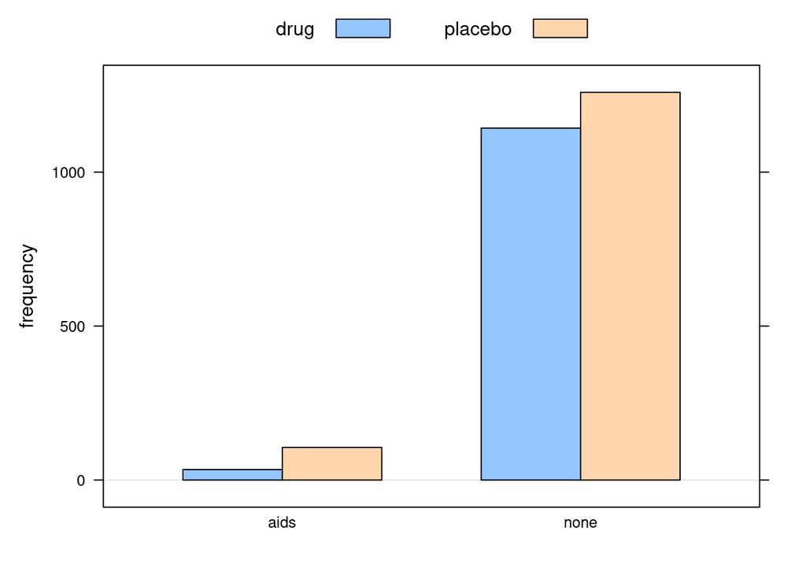

```r
barchartGC(~infected + treatment,data=drugUserData)
```

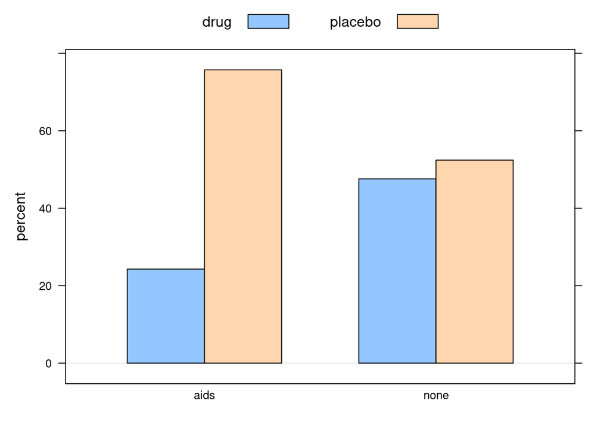

```r
barchartGC(~infected + treatment,data=drugUserData, type="percent")
```

The percentage of aid infection attributable to the drug is significantly reduced compared to the placebo, exhibiting over a 60% deviation in transmission rates

### Numerical Descriptive Results

```r
table1 <- xtabs(~infected + treatment,data=drugUserData)
rowPerc(table1)
```

```
##         treatment
## infected   drug placebo  Total
##     aids  24.29   75.71 100.00
##     none  47.59   52.41 100.00
```

```r
colPerc(table1)
```

```
##         treatment
## infected   drug placebo
##    aids    2.89    7.77
##    none   97.11   92.23
##    Total 100.00  100.00
```

## Inferential Results

```r
chisq.test(table1)
```

```
##
##  Pearson's Chi-squared test with Yates' continuity correction
##
## data:  table1
## X-squared = 27.955, df = 1, p-value = 1.242e-07
```

```r
chisqtestGC(table1)
```

```
## Pearson's Chi-squared test with Yates' continuity correction
##
## Observed Counts:
##         treatment
## infected drug placebo
##     aids   34     106
##     none 1143    1259
##
## Counts Expected by Null:
##         treatment
## infected    drug placebo
##     aids   64.82   75.18
##     none 1112.18 1289.82
##
## Contributions to the chi-square statistic:
##         treatment
## infected  drug placebo
##     aids 14.66   12.64
##     none  0.85    0.74
##
##
## Chi-Square Statistic = 27.955
## Degrees of Freedom of the table = 1
## P-Value = 0
```

```r
fisher.test(table1)
```

```
##
##  Fisher's Exact Test for Count Data
##
## data:  table1
## p-value = 4.23e-08
## alternative hypothesis: true odds ratio is not equal to 1
## 95 percent confidence interval:
##  0.2308342 0.5294225
## sample estimates:
## odds ratio
##  0.3534128
```

The p-value of 1.242e-07 is less than 0.05, then we have evidence that there is a statistically significant association between treatment and aids infection. According to the Pearson’s Chi-squared test with Yates’ continuity correction, while the amount of people contracting AIDS who received the placebo had 106 being infected with AIDS compared to the 34. The Fischer test yielded a p-value of 4.23e-08 which further supports that there is a statically significant association. Furthermore, the 95 percent confidence interval for an odds ratio does not include 1 providing further evidence that it is statistically significant

# Discussion and Conclusion